# CITS4009 Computational Data Analysis

### Conclusion

Clustering is an unsupervised learning technique used to group similar data points together based on their inherent similarities. Its purpose is to unveil natural patterns or groupings within the data without relying on a predefined target variable.

Hierarchical clustering proves to be particularly useful when the optimal number of clusters is unknown, allowing for an exploration of clustering behavior based on different distance metrics and linkage methods. The choice of distance and linkage depends on the characteristics of the data and the objectives of the analysis. In contrast, K-means clustering requires the user to specify the desired number of clusters beforehand.

Our clustering results exhibit a significant difference between the optimal choice of k = 10 from hierarchical clustering and k = 2 K-means clustering. It represents a trade-off between complexity and interpretability. Higher values of k can lead to more complex clusters, but the interpretation and insights may become challenging to discern. Conversely, a smaller k, such as k = 2, is easier to interpret but may oversimplify the underlying patterns, potentially leading to a loss of valuable information.

## Refferences

- Datacamp. Feature Selection in R with the Boruta R Package. https://www.datacamp.com/tutorial/feature-selection-R-boruta.
- Debarati Dutta. (2016, March 22). Boruta Package in R. https://www.analyticsvidhya.com/blog/2016/03/select-importantvariables-boruta-package/.
- OpenAI. (2023). ChatGPT [Large language model]. https://chat.openai.com/chat.
- GDP per capita (current US$). https://data.worldbank.org/indicator/NY.GDP.PCAP.CD.
- GDP per capita, current prices. https://www.imf.org/external/datamapper/NGDPDPC@WEO/OEMDC/ADVEC/WEOWORLD.

## Digital signature

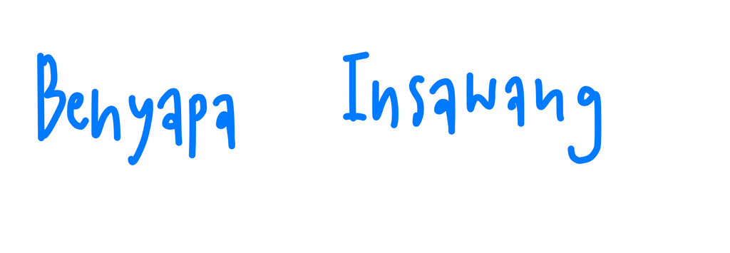

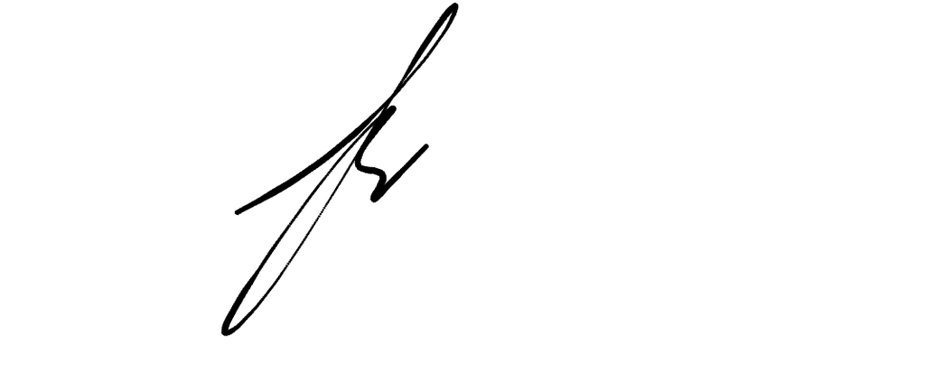